# N-gram Model

Srotaswati Panda

13/10/2019

## Summary

The goal here is to build a simple model for the relationship between words. This is the first step in building a predictive text mining application. The goal for this prediction model is to minimize both the size and runtime of the model in order to provide a reasonable experience to the user.

Tasks to accomplish:  
1. Exploratory analysis - distribution of words and relationship between words  
2. Frequencies of words and word pairs with figures and tables

```r
knitr::opts_chunk$set(echo = TRUE)
library(data.table)
library(ggplot2)
```

## Getting the data

The first step is to create a master source of the data from the link and store it in a separate folder.

```r
if(!file.exists("./data"))
    dir.create("data")
if(!file.exists("./data/swiftkey.zip")){
    fileurl<-"https://d396qusza40orc.cloudfront.net/dsscapstone/dataset/Coursera-SwiftKey.zip"
    download.file(fileurl,destfile = "./data/swiftkey.zip")
}
blogs_file<-"./data/final/en_US/en_US.blogs.txt"
news_file<-"./data/final/en_US/en_US.news.txt"
twitter_file<-"./data/final/en_US/en_US.twitter.txt"
if(!file.exists(blogs_file)&!file.exists(news_file)&!file.exists(twitter_file))
    unzip("./data/swiftkey.zip",exdir="./data")

blogs<-readLines(blogs_file,skipNul = TRUE)
news<-readLines(news_file,skipNul = TRUE)
twitter<-readLines(twitter_file,skipNul = TRUE)
textsource<-c(blogs,news,twitter)
```

## Exploratory Analysis

Next we make a summary statistics of the data sets for the number of sentences and determine the frequency of different words.

```r
#Week 1 quiz
#format(object.size(blogs),units = "MB")
#length(twitter)
#max(nchar(blogs))
#sum(grepl(" +love +",twitter))/sum(grepl(" +hate +",twitter))
#twitter[which(grepl(" +[Bb]iostats +",twitter)==TRUE)]
#sum(grepl("A computer once beat me at chess, but it was no match for me at kickboxing",twitter))

data.frame("File"=c("Blogs","News","Twitter"),"Size"=sapply(list(blogs,news,twitter), function(x){format(object.size(x),"MB")}),"Total characters"=sapply(list(blogs,news,twitter), function(x){sum(nchar(x))}),"Max characters"=sapply(list(blogs,news,twitter), function(x){max(unlist(lapply(x, function(y){nchar(y)})))}),"Total entries"=sapply(list(blogs,news,twitter), function(x){length(x)}))
```

```
##      File     Size Total.characters Max.characters Total.entries
## 1   Blogs 255.4 Mb        208361438          40835        899288
## 2    News  19.8 Mb         15683765           5760         77259
## 3 Twitter   319 Mb        162385035            213       2360148
```

```r
textdt<-data.table(textsource)
sentencelist<-unlist(strsplit(textdt$textsource,"(?<!\\w\\.\\w.)(?<![A-Z][a-z]\\.)(?<=\\.|\\?)\\s", perl=TRUE))
```

There are 5,865,486 sentences. The size of actual textsource is 0.6 Gb.

## Pre-processing for model

As the data is huge, only part of the data would be sampled. Next, the data is coverted into a list of words and cleaned of any numeric entities, punctuation marks, empty spaces, non-English characters.

```r
set.seed(1223)
sample_size<-0.05
lines<-sort(sample(1:length(textsource),round(length(textsource)*sample_size),replace=FALSE))
sampled<-textsource[lines]
sampled_dt<-data.table(sampled)

rm(blogs)
rm(twitter)
rm(news)
rm(sentencelist)
rm(textsource)

wordlist<-unlist(strsplit(tolower(sampled_dt$sampled)," "))
gc(verbose = getOption("verbose"), reset = FALSE, full = TRUE)
```

```
##            used  (Mb) gc trigger   (Mb)  max used   (Mb)
## Ncells  4211875 225.0   16312154  871.2  10845533  579.3
## Vcells 68769754 524.7  262962741 2006.3 262729181 2004.5
```

```r
wordlist<-gsub("^[12]{1}[0-9]{3}$","YYYY",wordlist)
wordlist<-gsub("^\\d+(,\\d*)*\\.*\\d*$","numeric",wordlist)
wordlist<-gsub("[[:punct:]]","",wordlist)
wordlist<-gsub("[^\x01-\x7F]+","",wordlist)
wordlist<-wordlist[!(wordlist=="")]
```

Next, we create a ready-table of unique words and assign a numerical code for each word by its frequency in the word list. The word and its corresponding code can be readily referenced by user-defined functions.

The wordscodes dictionary contains the actual word and its code sorted by frequency while the codes dictionary contains the words in the original order referenced by its code. The latter dictionary would be used to construct the multiple ngrams.

```r
wordfreq<-data.table(word=wordlist)
wordfreq[,freq:=.N,by=word]

rm(wordlist)
rm(sampled)

wordscodes = unique(copy(wordfreq))
setkey(wordscodes,freq)
wordscodes[,code:= nrow(wordscodes):1]
setkey(wordscodes,word)

wordtocode<-function(w){
    wlist<-list(w)
    wordscodes[wlist]$code
}
codetoword<-function(c){
    temp<-setkey(wordscodes,code)
    clist<-list(c)
    wordscodes[clist]$word
}

codes<-copy(wordfreq)
codes[,codex:=wordtocode(word)]
setnames(codes, old="codex", new="code")
setcolorder(codes, neworder = c("code","freq"))
```

## N-gram models

The following functions are used to get compute the next element in the data table and rotate. Multiple n-grams can be obtained by nesting the functions.

```r
rotatenum<-function(x){(1:x%%x)+1}
rotatevec<-function(v){v[rotatenum(length(v))]}
```

### Unigrams

[figure not shown]

```r
unigrams<-unique(copy(codes))
setkey(unigrams,code)
unigrams[,code:=NULL]
ggplot(data=unigrams[1:40,],aes(x=reorder(word,-freq),y=freq))+geom_bar(stat="identity")+labs(x="Unigram",y="Frequency")+theme(axis.text.x = element_text(angle=90))
```

### Bigrams

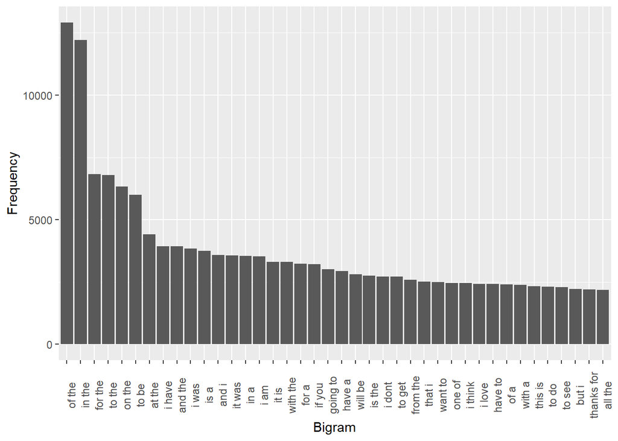

```r
bigrams <- data.table(w1 = codes$word, c1 = codes$code, c2 = rotatevec(codes$code))
bigrams[,freq:=.N,by=.(c1,c2)]
bigrams<-bigrams[,word:=paste(w1,codetoword(c2)," ")]
plotdata<-unique(bigrams[,c("word","freq")],by="word")
setkey(plotdata,freq)
ggplot(data=tail(plotdata,40),aes(x=reorder(word,-freq),y=freq))+geom_bar(stat="identity")+labs(x="Bigram",y="Frequency")+theme(axis.text.x = element_text(angle=90))
```

### Trigrams

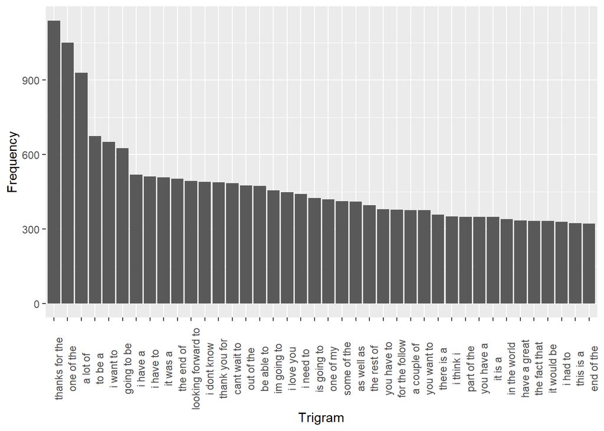

```r
trigrams <- data.table(w1 = codes$word, c1 = codes$code, c2 = rotatevec(codes$code),c3 = rotatevec(rotatevec(codes$code)))
trigrams[,freq:=.N,by=.(c1,c2,c3)]
trigrams<-trigrams[,word:=paste(w1,codetoword(c2),codetoword(c3)," ")]
plotdata<-unique(trigrams[,c("word","freq")],by="word")
setkey(plotdata,freq)
ggplot(data=tail(plotdata,40),aes(x=reorder(word,-freq),y=freq))+geom_bar(stat="identity")+labs(x="Trigram",y="Frequency")+theme(axis.text.x = element_text(angle=90))
```

### Quadgrams

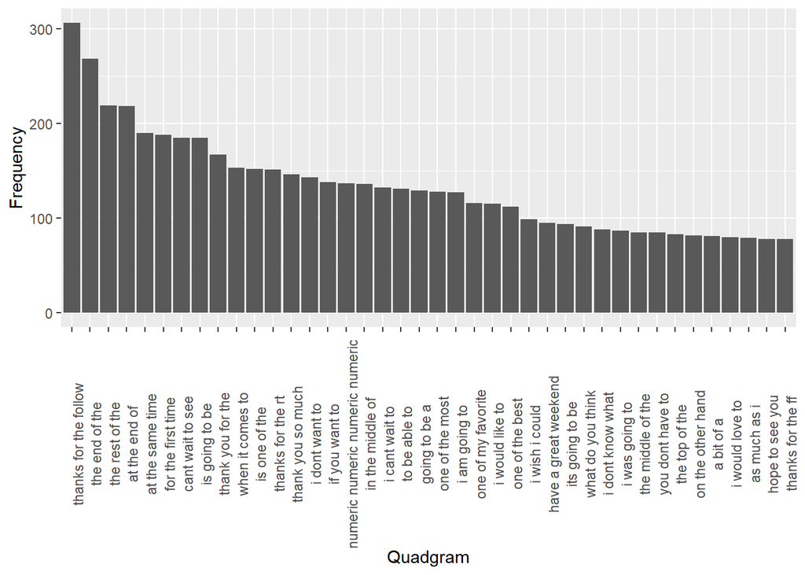

```r
quadgrams <- data.table(w1 = codes$word, c1 = codes$code, c2 = rotatevec(codes$code),c3 = rotatevec(rotatevec(codes$code)),c4 = rotatevec(rotatevec(rotatevec(codes$code))))
quadgrams[,freq:=.N,by=.(c1,c2,c3,c4)]
quadgrams<-quadgrams[,word:=paste(w1,codetoword(c2),codetoword(c3),codetoword(c4)," ")]
plotdata<-unique(quadgrams[,c("word","freq")],by="word")
setkey(plotdata,freq)
ggplot(data=tail(plotdata,40),aes(x=reorder(word,-freq),y=freq))+geom_bar(stat="identity")+labs(x="Quadgram",y="Frequency")+theme(axis.text.x = element_text(angle=90))
```

### Pentagrams

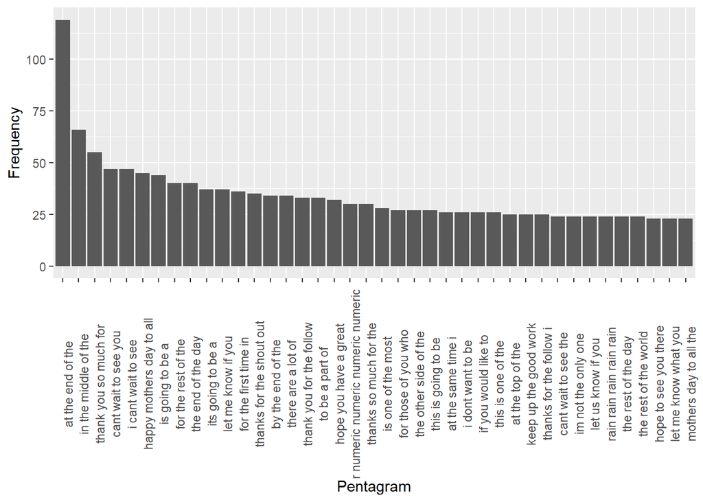

```r
pentagrams <- data.table(w1 = codes$word, c1 = codes$code, c2 = rotatevec(codes$code),c3 = rotatevec(rotatevec(codes$code)),c4 = rotatevec(rotatevec(rotatevec(codes$code))),c5 = rotatevec(rotatevec(rotatevec(rotatevec(codes$code)))))
pentagrams[,freq:=.N,by=.(c1,c2,c3,c4,c5)]
pentagrams<-pentagrams[,word:=paste(w1,codetoword(c2),codetoword(c3),codetoword(c4),codetoword(c5)," ")]
plotdata<-unique(pentagrams[,c("word","freq")],by="word")
setkey(plotdata,freq)
ggplot(data=tail(plotdata,40),aes(x=reorder(word,-freq),y=freq))+geom_bar(stat="identity")+labs(x="Pentagram",y="Frequency")+theme(axis.text.x = element_text(angle=90))
```

```r
rm(plotdata)
```

## Summary and Futher Work

Working with the complete source takes a lot of time and hence only 5% of the data was sampled here. Some workarounds was using cached chunks and removing large files after use which freed internal memory. If sampling size and ngram length was higher, there were errors with knitting the file as the matrix sizes increased non-linearly. This was partly solved by running the individual code chunks through the console first.

Another possible method to create the ngrams would be to work with the tm(text mining) library and RWeka libraries to avoid creating huge vectors.

The code could be further refined to make generalized functions to find ngrams. While creating the app, and given a string of words by the user, the idea would be look at strings of three or four words for the most likely word to follow. A further improvement would be to investigate if any phrases with emojis, interjections and other unusual strings occur, especially in the twitter source. A concern would be running the Shiny App in optimal time.